# TASK 5 [EDA]

```python
import numpy as np
import pandas as pd
import matplotlib.pyplot as plt
import seaborn as sns
```

```python
data = pd.read_csv(r"C:\Users\hp\Downloads\titanic_dataset.csv")
print(data)
```

```
     PassengerId  Survived  Pclass  \
0              1         0       3
1              2         1       1
2              3         1       3
3              4         1       1
4              5         0       3
..           ...       ...     ...
886          887         0       2
887          888         1       1
888          889         0       3
889          890         1       1
890          891         0       3

                                                  Name     Sex   Age  SibSp  \
0                              Braund, Mr. Owen Harris    male  22.0      1
```

[output cut: 25 more lines]

```python
data.describe()
```

|  | PassengerId | Survived | Pclass | Age | SibSp | Parch | Fare |
| --- | --- | --- | --- | --- | --- | --- | --- |
| count | 891.000000 | 891.000000 | 891.000000 | 714.000000 | 891.000000 | 891.000000 | 891.000000 |
| mean | 446.000000 | 0.383838 | 2.308642 | 29.699118 | 0.523008 | 0.381594 | 32.204208 |
| std | 257.353842 | 0.486592 | 0.836071 | 14.526497 | 1.102743 | 0.806057 | 49.693429 |
| min | 1.000000 | 0.000000 | 1.000000 | 0.420000 | 0.000000 | 0.000000 | 0.000000 |
| 25% | 223.500000 | 0.000000 | 2.000000 | 20.125000 | 0.000000 | 0.000000 | 7.910400 |
| 50% | 446.000000 | 0.000000 | 3.000000 | 28.000000 | 0.000000 | 0.000000 | 14.454200 |
| 75% | 668.500000 | 1.000000 | 3.000000 | 38.000000 | 1.000000 | 0.000000 | 31.000000 |
| max | 891.000000 | 1.000000 | 3.000000 | 80.000000 | 8.000000 | 6.000000 | 512.329200 |

```python
data.describe(include="all")
```

|  | PassengerId | Survived | Pclass | Name | Sex | Age | SibSp | Parch | Ticket | Fare | Cabin | Embarked |
| --- | --- | --- | --- | --- | --- | --- | --- | --- | --- | --- | --- | --- |
| count | 891.000000 | 891.000000 | 891.000000 | 891 | 891 | 714.000000 | 891.000000 | 891.000000 | 891 | 891.000000 | 204 | 889 |
| unique | NaN | NaN | NaN | 891 | 2 | NaN | NaN | NaN | 681 | NaN | 147 | 3 |
| top | NaN | NaN | NaN | Dooley, Mr. Patrick | male | NaN | NaN | NaN | 347082 | NaN | G6 | S |
| freq | NaN | NaN | NaN | 1 | 577 | NaN | NaN | NaN | 7 | NaN | 4 | 644 |
| mean | 446.000000 | 0.383838 | 2.308642 | NaN | NaN | 29.699118 | 0.523008 | 0.381594 | NaN | 32.204208 | NaN | NaN |
| std | 257.353842 | 0.486592 | 0.836071 | NaN | NaN | 14.526497 | 1.102743 | 0.806057 | NaN | 49.693429 | NaN | NaN |
| min | 1.000000 | 0.000000 | 1.000000 | NaN | NaN | 0.420000 | 0.000000 | 0.000000 | NaN | 0.000000 | NaN | NaN |
| 25% | 223.500000 | 0.000000 | 2.000000 | NaN | NaN | 20.125000 | 0.000000 | 0.000000 | NaN | 7.910400 | NaN | NaN |
| 50% | 446.000000 | 0.000000 | 3.000000 | NaN | NaN | 28.000000 | 0.000000 | 0.000000 | NaN | 14.454200 | NaN | NaN |
| 75% | 668.500000 | 1.000000 | 3.000000 | NaN | NaN | 38.000000 | 1.000000 | 0.000000 | NaN | 31.000000 | NaN | NaN |
| max | 891.000000 | 1.000000 | 3.000000 | NaN | NaN | 80.000000 | 8.000000 | 6.000000 | NaN | 512.329200 | NaN | NaN |

```python
data.info()
```

```
<class 'pandas.core.frame.DataFrame'>
RangeIndex: 891 entries, 0 to 890
Data columns (total 12 columns):
 #   Column       Non-Null Count  Dtype
---  ------       --------------  -----
 0   PassengerId  891 non-null    int64
 1   Survived     891 non-null    int64
 2   Pclass       891 non-null    int64
 3   Name         891 non-null    object
 4   Sex          891 non-null    object
 5   Age          714 non-null    float64
 6   SibSp        891 non-null    int64
 7   Parch        891 non-null    int64
 8   Ticket       891 non-null    object
 9   Fare         891 non-null    float64
 10  Cabin        204 non-null    object
 11  Embarked     889 non-null    object
dtypes: float64(2), int64(5), object(5)
memory usage: 83.7+ KB
```

### Visualising Columns ("Survived","Sex")

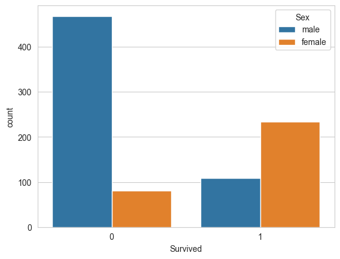

```python
sns.countplot(x="Survived",hue = "Sex" , data= data )
plt.savefig("countplot_survived.png")
plt.show()
```

#### The above countplot we can observe that Male who could'nt survive is more than 450 wherein the Female is below 100.

#### Similarly in those who survived the count of Female is more than 200 wherein the count of Male is just crossed 100.

```python
data.isnull().sum()
```

```
PassengerId      0
Survived         0
Pclass           0
Name             0
Sex              0
Age            177
SibSp            0
Parch            0
Ticket           0
Fare             0
Cabin          687
Embarked         2
dtype: int64
```

# Visualizing the null values in the dataset

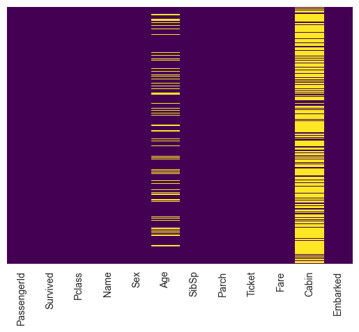

```python
sns.heatmap(data.isnull(),yticklabels=False , cbar = False ,cmap  ="viridis")
plt.savefig("null_val_heatmap.png")
plt.show()
```

## By the above outputs we can understand that the data set has continous and categorical variables , null values :

- "name","sex" ,"ticket" ,"cabin", "embarked" are categorical variables
- "age","cabin","embarked" has nul values

#### Finding the count of each category in col "Embarked" and visualizing it

```python
data["Embarked"].value_counts()
```

```
Embarked
S    644
C    168
Q     77
Name: count, dtype: int64
```

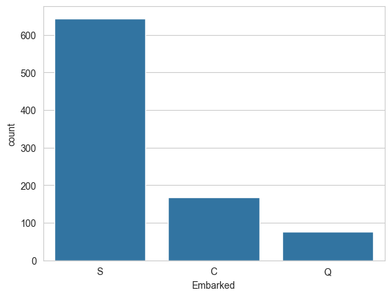

```python
sns.countplot(x="Embarked", data=data)
plt.savefig("countplot_embarked.png")
plt.show()
```

#### we can see that the category "S" is the dominating one .

### Analysing the "Age" column to handel the missing values

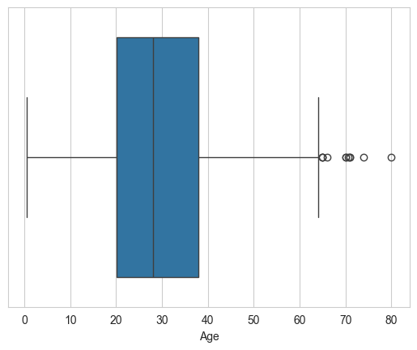

```
np.float64(28.0)
```

```python
sns.boxplot(x= "Age", data=data)
plt.savefig("boxplot_age.png")
plt.show()
data.Age.median()
```

### Analysing the age of passengers based on sex and Pclass

this gives us the more specific information about the age distribution among passengers

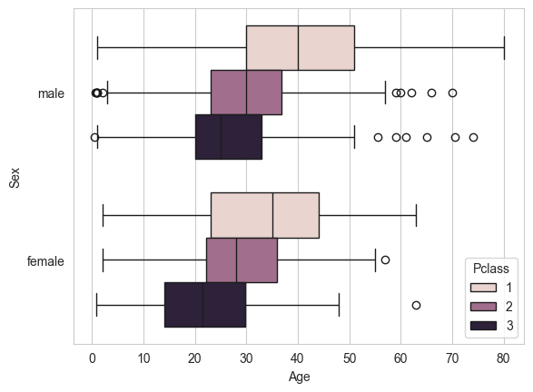

```
Sex     Pclass
female  1         35.0
        2         28.0
        3         21.5
male    1         40.0
        2         30.0
        3         25.0
Name: Age, dtype: float64
```

```python
sns.boxplot(x= "Age",y= "Sex", hue = "Pclass", data=data)
plt.savefig("boxplt(age,sex,pclass).png")
plt.show()
data.groupby(["Sex","Pclass"])["Age"].median()
```

## HANDELLING MISSING VALUES

#### "cabin" has a lot of null values we don't require for analysis

#### "embarked" is a categorious variable and has only 3 unique caterories we fill the null values with the mode of col vlues = "s"

```python
data = data.drop(["Cabin"], axis =1)
```

```python
data["Embarked"] = data["Embarked"].fillna(data["Embarked"].mode()[0])
```

```python
def null_age(col):
    Age = col.iloc[0]
    Sex = col.iloc[1]
    Pclass = col.iloc[2]

    if pd.isnull(Age):
        if Sex == 'female':
            if Pclass == 1:
                return 32
            else:
                return 28

        else:  # female
            if Pclass == 1:
                return 36
            elif Pclass == 2:
                return 29
            else:
                return 28
    else:
        return Age


data['Age'] = data[['Age', 'Sex', 'Pclass']].apply(null_age, axis=1)
```

### Droping other unwanted columns ["PassengerId" ,"Name","Ticket"]

```python
data= data.drop(["PassengerId" ,"Name","Ticket"] , axis = 1)
```

```python
print(data)
```

```
     Survived  Pclass     Sex   Age  SibSp  Parch     Fare Embarked
0           0       3    male  22.0      1      0   7.2500        S
1           1       1  female  38.0      1      0  71.2833        C
2           1       3  female  26.0      0      0   7.9250        S
3           1       1  female  35.0      1      0  53.1000        S
4           0       3    male  35.0      0      0   8.0500        S
..        ...     ...     ...   ...    ...    ...      ...      ...
886         0       2    male  27.0      0      0  13.0000        S
887         1       1  female  19.0      0      0  30.0000        S
888         0       3  female  28.0      1      2  23.4500        S
889         1       1    male  26.0      0      0  30.0000        C
890         0       3    male  32.0      0      0   7.7500        Q

[891 rows x 8 columns]
```

### Confirming the changes

```python
data.describe(include ="all")
```

|  | Survived | Pclass | Sex | Age | SibSp | Parch | Fare | Embarked |
| --- | --- | --- | --- | --- | --- | --- | --- | --- |
| count | 891.000000 | 891.000000 | 891 | 891.000000 | 891.000000 | 891.000000 | 891.000000 | 891 |
| unique | NaN | NaN | 2 | NaN | NaN | NaN | NaN | 3 |
| top | NaN | NaN | male | NaN | NaN | NaN | NaN | S |
| freq | NaN | NaN | 577 | NaN | NaN | NaN | NaN | 646 |
| mean | 0.383838 | 2.308642 | NaN | 29.600640 | 0.523008 | 0.381594 | 32.204208 | NaN |
| std | 0.486592 | 0.836071 | NaN | 13.057013 | 1.102743 | 0.806057 | 49.693429 | NaN |
| min | 0.000000 | 1.000000 | NaN | 0.420000 | 0.000000 | 0.000000 | 0.000000 | NaN |
| 25% | 0.000000 | 2.000000 | NaN | 22.000000 | 0.000000 | 0.000000 | 7.910400 | NaN |
| 50% | 0.000000 | 3.000000 | NaN | 28.000000 | 0.000000 | 0.000000 | 14.454200 | NaN |
| 75% | 1.000000 | 3.000000 | NaN | 36.000000 | 1.000000 | 0.000000 | 31.000000 | NaN |
| max | 1.000000 | 3.000000 | NaN | 80.000000 | 8.000000 | 6.000000 | 512.329200 | NaN |

## Ploting the HEATMAP of CORRELATION MATRIC for with the numerical variables of dataset

```python
data['Embarked_'] = data['Embarked'].astype('category').cat.codes
data['Sex_'] = data['Sex'].astype('category').cat.codes
```

```
           Survived    Pclass       Age     SibSp     Parch      Fare  \
Survived   1.000000 -0.338481 -0.065389 -0.035322  0.081629  0.257307
Pclass    -0.338481  1.000000 -0.366690  0.083081  0.018443 -0.549500
Age       -0.065389 -0.366690  1.000000 -0.239450 -0.180239  0.104228
SibSp     -0.035322  0.083081 -0.239450  1.000000  0.414838  0.159651
Parch      0.081629  0.018443 -0.180239  0.414838  1.000000  0.216225
Fare       0.257307 -0.549500  0.104228  0.159651  0.216225  1.000000
Embarked_ -0.167675  0.162098 -0.023188  0.068230  0.039798 -0.224719
Sex_      -0.543351  0.131900  0.087963 -0.114631 -0.245489 -0.182333

           Embarked_      Sex_
Survived   -0.167675 -0.543351
Pclass      0.162098  0.131900
Age        -0.023188  0.087963
SibSp       0.068230 -0.114631
Parch       0.039798 -0.245489
Fare       -0.224719 -0.182333
Embarked_   1.000000  0.108262
Sex_        0.108262  1.000000
```

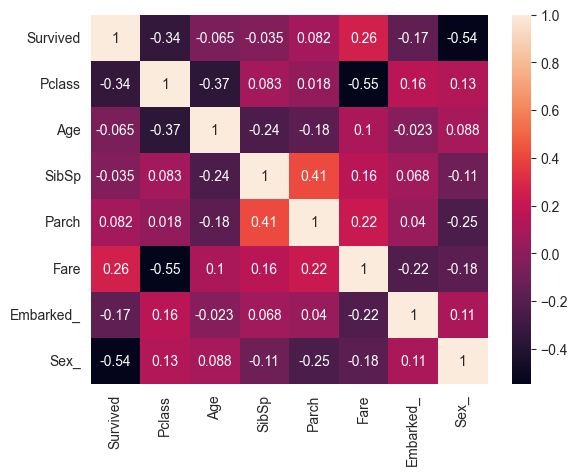

```python
num_col = data.select_dtypes(include = ["number","category"])
cor=num_col.corr()
print(cor)

sns.heatmap(cor,annot=True)
plt.savefig("cor_heatmap.png")
plt.show()
```

#### * negative correlatin anomg "sex" ,"survived"

#### * little positive correlation among "fare" and "survived"

#### * positive correlation among "parch" and "sibsp"

#### But most of the variables are NEUTRAL.

## PAIR PLOT

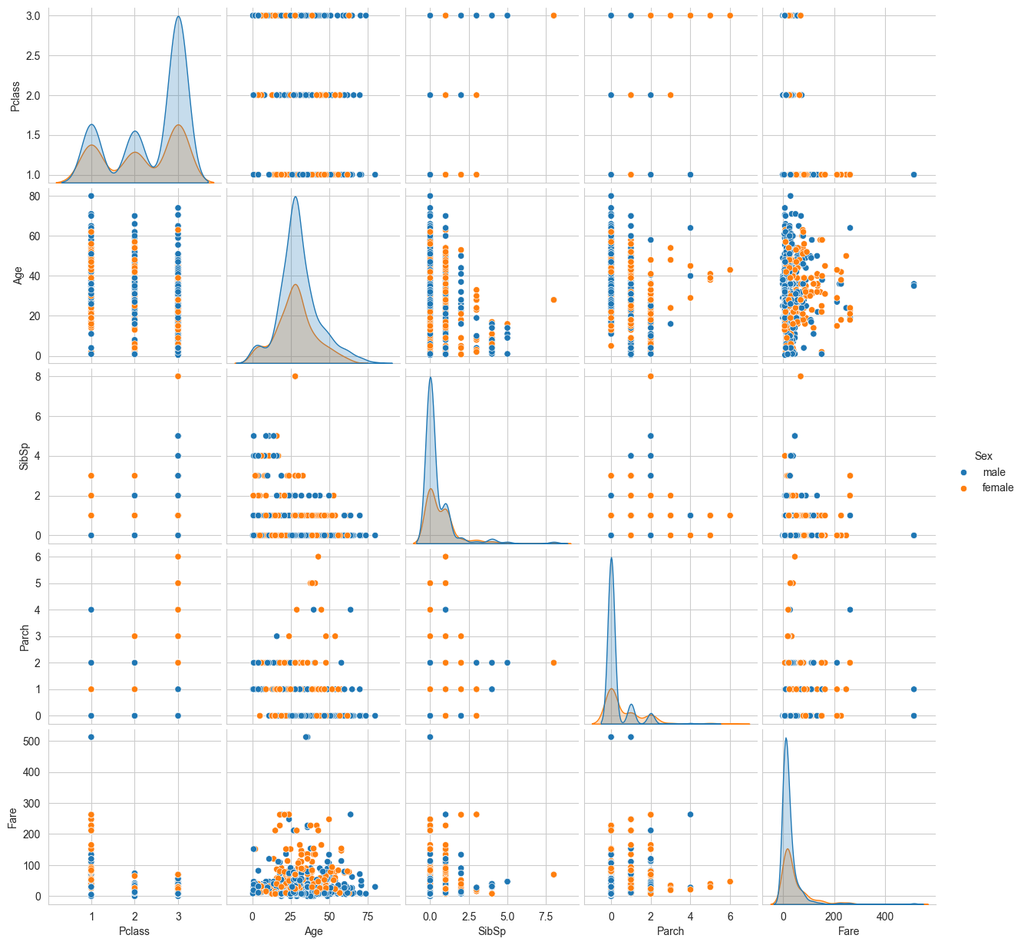

```python
sns.pairplot(data, vars= ["Pclass" ,"Age","SibSp","Parch","Fare"],  hue ="Sex")
plt.savefig("pairplot_hue=Sex.png")
plt.show()
```

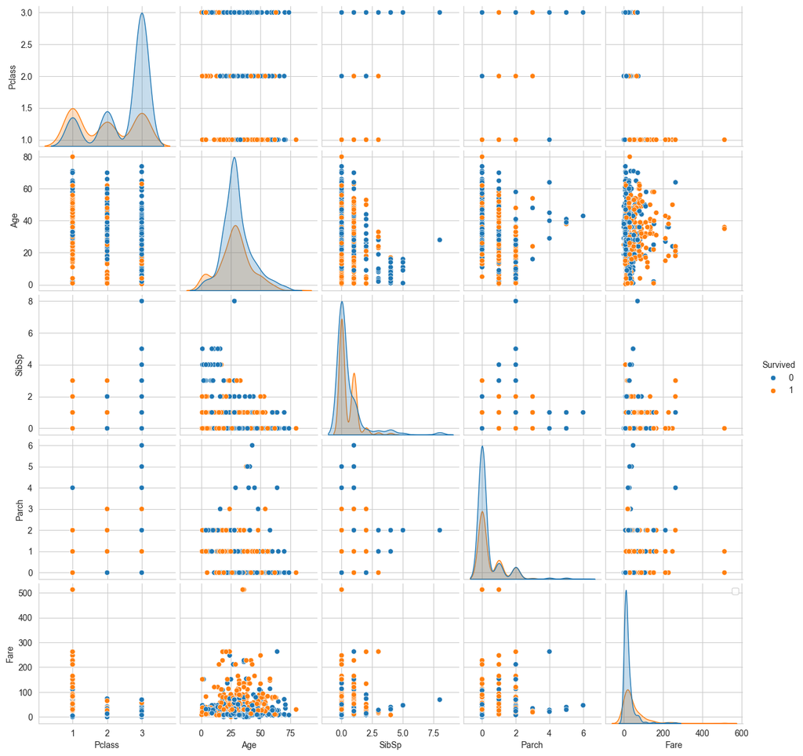

```python
sns.pairplot(data, vars= ["Pclass" ,"Age","SibSp","Parch","Fare"],  hue ="Survived")
plt.legend()
plt.savefig("pairplot_hue=SURVIVED.png")
plt.show()
```